# What field am I in again…?

B. E. Green

2022-09-19

## TLDR

Psychology, Information Science, Political Science, Communications? At this point, my actual field of study is blurry even to me.

I recently attended the [American Political Science Association](https://www.apsanet.org/) Conference held in Montréal, which was one of the first bigger conferences I’ve been able to attend as a doctoral student who started their graduate journey in the middle of the COVID-19 pandemic (i.e. completely virtual). Feeling a bit alone and out-of-place as an Information Science student among Political Scientists, I had ample time to reflect on where I was situated (figuratively and literally).

### Fields

- **Psychology** – the study of the mind and behavior
- **Communications** – the study of human messaging, whether through verbal or non-verbal methods
- **Political Science** – the study of theoretical and/or practical aspects of government and politics at varying levels (local, state, national, international)
- **Information Science** – *a bit more abstract*, the study of information systems as they relate to social, cultural, economic, legal, historical and political contexts

Somewhere within these four fields you will find me sitting on a chair swinging my short legs. If you, reader, so happen to engage with one of these fields, please feel free to claim your favorite color of the four.

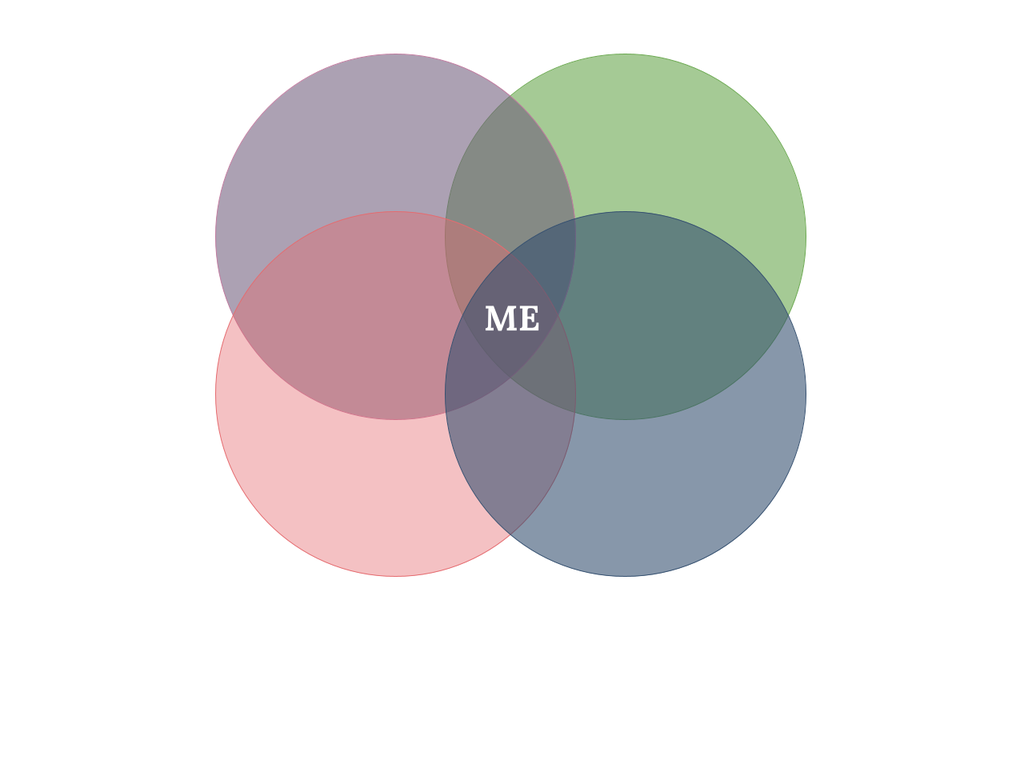

Four Circle Venn Diagram

### Situatedness

When I share my background is in Psychology as opposed to other computing fields, people are usually surprised! If you scan my [home page](https://bregreen.github.io/) you’d see I earned both my B.S. and M.S. in Psychology from [Prairie View A&M University](https://www.pvamu.edu/cojjp/departments/psychology/) and the [University of Texas at San Antonio](https://hcap.utsa.edu/psychology/), respectively. I’ve known I was going to study psychology since the fourth grade – no seriously, I have a collage poster project about “Future Me” where I said I planned on being a psychiatrist by 22. While missing the mark on that lofty timeline, I never wavered in my first field of choice. I love *nearly* everything about the field and knew I would thrive in that area. At the time, it was also pretty evident to me that holding solely a Bachelors in Psychology wasn’t going to do a lot for my future career trajectories and graduate school was always in the cards.

Thankfully, coming out of my Masters I was quickly offered a role as a Research Analyst. I worked in this position for close to three years, with an amazing team and the best boss in the world! There I learned to code (SQL, Python, R), how to work with administration/faculty/staff and the local community, developed my leadership skills, and had a salary that could at least pay my student loans and let me survive. I was more than happy; inching closer and closer to the “settled and content” space of adulthood. *Yet* grad school was ever-looming in the back of my mind. Finally, one day I broke down and admitted to my boss that I needed to go… I needed to try grad school, whether or not I would actually stay. Without hesitation she supported and encouraged me – I cannot thank her enough to this day.

Initially, I considered applying only to Communications programs for graduate school because it seemed like they were using methods of interest or working on fascinating problems. I won’t spend this post discussing how I applied to grad school or how I decided to apply to Cornell (if I do in the future, I’ll link it here), but I will say I didn’t know of Information Science before 2020! Whatever the case, I applied, I got in, and here I stand. Cornell Information Science is curious hodgepodge of sorts, which is probably why I fit strangely well. My main advisor is situated in the Communications department while my minor members are a blend of Government and Psychology. So, we return to the question: what am I? Psychology, Information Science, Political Science, or Communications?

[Return to Blog Home Page](https://bregreen.github.io/blog.html#)